# Don’t fear learning Data Visualization in R with ggplot

geze

10/16/2019

## Yet another great free-software tool.

I will show you the power of one `R` plotting library `ggplot`. Quoting Wikipedia, `ggplot` is a data visualization package for `R` created by Hadley Wickham in 2005, `ggplot2` is an implementation of Leland Wilkinson’s Grammar of Graphics. If you want to dive deeper, I recommend “**Data Visualization: A Practical Introduction**” by K. Healy because it is listed by the Society of Actuaries SOA for their PA-exam. This is a file written in [Rstudio](http://rmarkdown.rstudio.com).

The purpose here is to explain the structure of the global syntax of `ggplot` by building an example of a **scatterplot** with many of its common elements. I will use a dataset of houses obtained from **github.com/ageron**, which was not originally intended for this purpose. I will plot the longitude vs the latitude, and color the markers by their classification in another feature measuring the proximity to the ocean.

First **install** the library **tidyverse** with `install.packages("tidyverse")` and load it with `library(tidyverse)`. This includes the library **ggplot2**, which is the main object of this tutorial. I will be using the csv file obtained [here](https://raw.githubusercontent.com/ageron/handson-ml2/master/datasets/housing/housing.tgz).

## The first plot

Our first plot will begin by loading the library `tidyverse`.

```r
library(tidyverse)
```

```r
housing <- read_csv("~/ml/data/housing.csv")
```

Finally, we will make our first own plot using the attributes longitude and latitude. Notice that first we call the function `ggplot`, which loads the data. It also contains the aesthetic function `aes` telling `R` which is our `X` variable, which is our `Y` variable, and another variable `color` to be explained later. Then we use the function `geom_point()` to tell R actually to make a scatterplot.

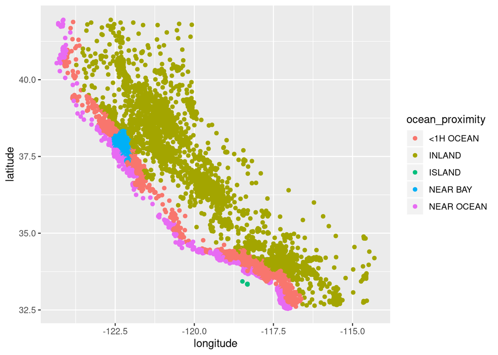

```r
ggplot(data = housing, mapping = aes(x = longitude, y = latitude, color = ocean_proximity)) + geom_point()
```

*Remark*: The option `color` in `aes` does not choose what color will be used, but it tells `R` to use different colors for the different classes in the attribute `ocean_proximity`.

Just to make sure that we understand `ocean_proximity`, we do a histogram of it. This attribute classify the houses by their relative location to water formations. It has 5 class: (1) Near Ocean. (2) <1H Ocean or at a distance less than an hour from the ocean. (3) Near Bay. (4) Island. (5) Inland. Here one may opt using the library `plpr` for a table of frequencies.

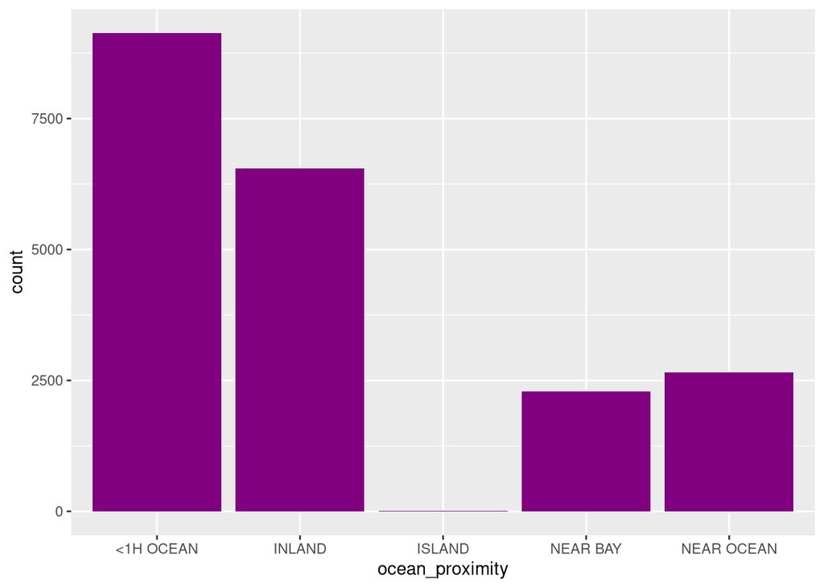

```r
ggplot(data = housing, aes(ocean_proximity)) + geom_bar(fill =  "#800080" )+ labs(tittle = "Frequency of Ocean Proximity Values")
```

## Overview of the syntax

The main elements of a plot are:

1. `ggplot(data, aes(X,Y,color,fill)` where`data` is usually the table variable; `X` and `Y` are some attributes in our table; `color` and `fill` tell `R` to color based on a classifying attribute, the former is for dots, and the later for areas.
2. `geom_<type>` is to decide the type or types of graph(s) that we will use.
- `geom_point(alpha = 0.d, color, shape, size, line_type)` is for scatterplots.
- `geom_bar(color, shape, size, line_type)` is for bars.
- `geom_boxplot(color, shape, size, line_type)` is for boxplots.
- `geom_smooth(color, se = boolean, size, method, formula, mapping)` is for optimization models. Some methods are `lm` for linear models, `gam` for generalized additive models, `loess`.
3. `cord_cartesian(xlim = c(a,b), ylim= c(c,d))` to delimit the region of the cartesian plane to observe.
4. `scale_x_log10`, `scale_x_reverse`, `scale_x_sqr` or their respective ones for `y` to adjust the scales.
5. `labs(x, y, tittle, subtittle)` to add labels to the plot.
6. `ggsave(filename, plot_variable_name)`

Finally, recall that you add all these elements, and write `+` at the end of the line, so R understands that there is more code coming.

## A much better graph.

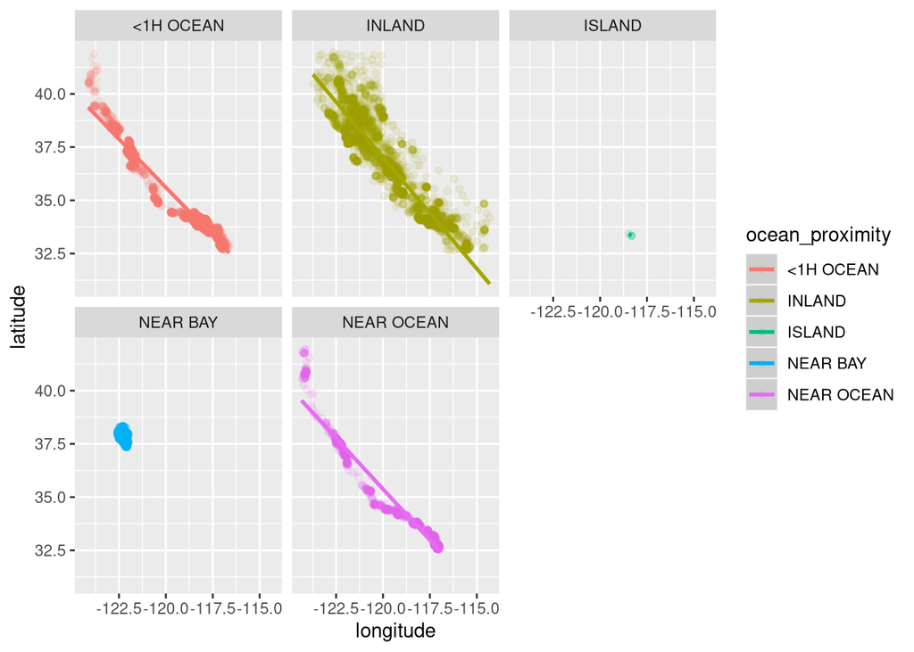

```r
ggplot(data = housing, mapping = aes(x = longitude, y = latitude, color = ocean_proximity)) + geom_point(alpha = 0.1) + geom_smooth(method = 'lm') + labs(x = "longitude", y = "latitude", tittle = "location of the houses", subtittle = "sorted by proximity to the ocean") + facet_wrap(~ocean_proximity)
```

Notice the last option `facet_wrap(~ocean_proximity)` allows us to do one graph per class in the attribute `ocean_proximity`.